# Group2_health_sleep_question

### Project 2: Instructions on the Data Set: Health and Sleep Data Analysis

([Click here to download the csv file](https://www.kaggle.com/datasets/hanaksoy/health-and-sleep-statistics))

#### Part 1: Introduction

- Write a brief objective of the project and give an introduction about your data set.
- Provide the link to your data set.
- Add necessary references

#### Part 2: Data Wrangling

1. **Loading the Dataset:**
   - Save the CSV file as `Health_Sleep_Statistics`.
   - Load the dataset from the CSV file and dave it as `df`.
2. **Inspect the Data:**
   - Display the first 5 rows of the dataset.
   - Print column names and Data types.
   - Identify and count the number of duplicate rows in a Pandas DataFrame.
   - Identify and count the number of missing values.
3. **Data Cleaning:**
   - Copy the original data frame (`df`) to new data frame and name it as `df_new`.
   - Drop the duplicates if you have any.
   - Determine a suitable way to handle missing values, either by filling, dropping, or imputing them.
4. **Feature Engineering:**
   - Create a new feature called `Sleep Duration` that calculates the total hours of `sleep based` on the `Bedtime` and `Wake-up Time.`
     - To calculuate Sleep Duration: $Sleep\;Duration = \frac{Wake \; up \; Time - Bedtime}{3600}$

     *Hint: Make sure to convert data types of `Bedtime` and `Wake-up Time` to datetime format and use `dt.total_seconds()` to count the total hours*
5. Once finish all the task in Part 2, print the first 5 rows of the DataFrame.

#### Part 3: Data Analysis and Exploration

1. **Summary Statistics:**
   - Calculate summary statistics for numerical columns using appropriate `built-in` python code.
2. **Group Analysis**
   - Create a new column called `age_group` to categorize users into age groups: `<18, 18-30, 30-45, 45-60`, and `60+` and display first 5 rows.
3. **Save the Cleaned Dataset**
   - Once finished above steps, copy the data frame (`df_new`) to another data frame and name it as `df_cleaned` and save the cleaned data set as a csv file named `Health_Sleep_Statistics_cleaned`

#### Part 4: Data Visualization and Story Telling

You can use Seaborn or Matplotlib for visualization. Add appropriate **title, labels** for each visualization and make the attractive plots. All labels should be easily readable. **Interpret** each of the visualization.

1. **Line Plot for Average Daily Steps by Age Group**
   - Create a line plot to observe trends in Average Daily Steps over age.
2. **Calories Burned vs. Daily Steps**
   - Create a scatter plot to explore the relationship between Calories Burned and Daily Steps colored by gender.
3. **Correlation Heatmap:**
   - Generate a heatmap to examine the correlations between numeric variables.
4. **Create a countplot plot to investigate instances of Sleep Disorders by Physical Activity Level**
   - *See the expected output for this plot:*

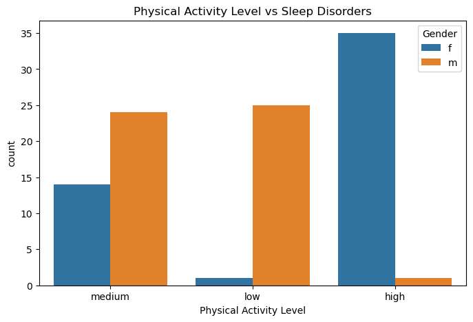

```python
#EXPECTED OUTPUT
```

### BONUS POINT

#### EXPECTED OUTPUT

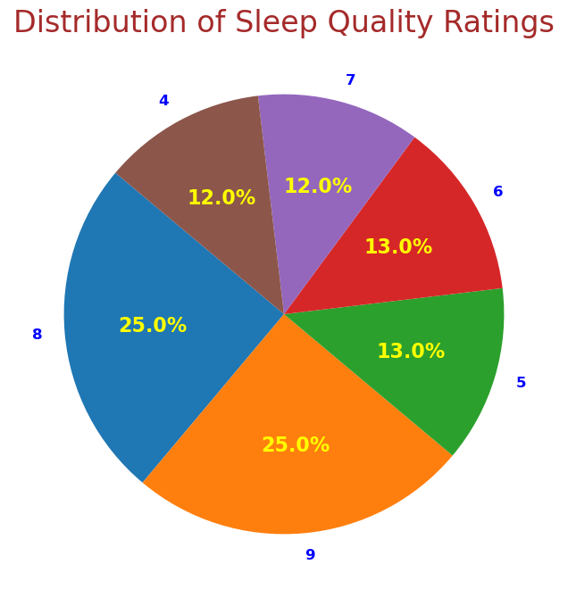

```python
#EXPECTED OUTPUT:
```

#### Note: Add additional visualizations if you discover other interesting trends or patterns.

### Part 5: Conclusions

- Write a short report summarizing your findings from the analysis.
- Highlight any interesting patterns or relationships you observed in the dataset.
- Suggest potential next steps or further analyses that could be performed on this data.